# Introduction to Pandas, Part 2

Advanced Pandas syntax, aggregation, and joining.

```python
%matplotlib inline
import matplotlib.pyplot as plt
import seaborn as sns
import numpy as np
import pandas as pd
from IPython.display import display

plt.style.use('fivethirtyeight')
sns.set_context("notebook")
```

Let's start by loading the California baby names again.

```python
import urllib.request
import os.path
import zipfile

data_url = "https://www.ssa.gov/oact/babynames/state/namesbystate.zip"
local_filename = "babynamesbystate.zip"
if not os.path.exists(local_filename): # if the data exists don't download again
    with urllib.request.urlopen(data_url) as resp, open(local_filename, 'wb') as f:
        f.write(resp.read())

zf = zipfile.ZipFile(local_filename, 'r')

ca_name = 'CA.TXT'
field_names = ['State', 'Sex', 'Year', 'Name', 'Count']
with zf.open(ca_name) as fh:
    babynames = pd.read_csv(fh, header=None, names=field_names)

babynames.sample(5)
```

|  | State | Sex | Year | Name | Count |
| --- | --- | --- | --- | --- | --- |
| 93934 | CA | F | 1983 | Ying | 5 |
| 285204 | CA | M | 1979 | Howard | 69 |
| 182581 | CA | F | 2008 | Suzanne | 18 |
| 206116 | CA | F | 2014 | Madelynn | 72 |
| 131780 | CA | F | 1995 | Tiara | 68 |

Goal 1: Find the most popular baby name in California in 2018

```python
babynames[babynames["Year"] == 2018].sort_values(by = "Count", ascending = False).head(5)
```

|  | State | Sex | Year | Name | Count |
| --- | --- | --- | --- | --- | --- |
| 221154 | CA | F | 2018 | Emma | 2741 |
| 382082 | CA | M | 2018 | Noah | 2567 |
| 221155 | CA | F | 2018 | Mia | 2497 |
| 221156 | CA | F | 2018 | Olivia | 2464 |
| 382083 | CA | M | 2018 | Liam | 2411 |

```python
babynames[babynames["Year"] == 2018].sort_values(by = "Count").tail(5)
```

|  | State | Sex | Year | Name | Count |
| --- | --- | --- | --- | --- | --- |
| 382083 | CA | M | 2018 | Liam | 2411 |
| 221156 | CA | F | 2018 | Olivia | 2464 |
| 221155 | CA | F | 2018 | Mia | 2497 |
| 382082 | CA | M | 2018 | Noah | 2567 |
| 221154 | CA | F | 2018 | Emma | 2741 |

## Goal 2: Find baby names that start with j.

### Approach 1: Combine lecture 4 syntax with CS61A/CS88 ideas.

```python
babynames["Name"].head(20)
```

```
0          Mary
1         Helen
2       Dorothy
3      Margaret
4       Frances
5          Ruth
6        Evelyn
7         Alice
8      Virginia
9     Elizabeth
10     Florence
11        Marie
12      Mildred
13         Rose
14        Hazel
15       Louise
16    Josephine
17      Lucille
18        Grace
19       Gladys
Name: Name, dtype: object
```

```python
starts_with_j = [ x.startswith('J') for x in babynames["Name"]]
#starts_with_j = [ x[0] == 'J'       for x in babynames["Name"]]  # Alternative. Why?
starts_with_j[:20]
```

```
[False,
 False,
 False,
 False,
 False,
 False,
 False,
 False,
 False,
 False,
 False,
 False,
 False,
 False,
 False,
 False,
 True,
 False,
 False,
 False]
```

```python
starts_with_j = [x.startswith('J') for x in babynames["Name"]]
babynames[starts_with_j].sample(5)
```

|  | State | Sex | Year | Name | Count |
| --- | --- | --- | --- | --- | --- |
| 321790 | CA | M | 1996 | Joe | 196 |
| 292076 | CA | M | 1983 | Jamie | 104 |
| 42014 | CA | F | 1959 | Janise | 5 |
| 128127 | CA | F | 1994 | Jacklyn | 68 |
| 190934 | CA | F | 2010 | Jessa | 18 |

```python
j_names = babynames[ [x.startswith('J') for x in babynames["Name"]] ]
```

### Approach 2: Use the Series.str methods.

First, what are these special `str` things in there??

```python
s = babynames["Name"].str
n = "Jane" # a Simple string, so we can compare...
```

```python
s  # Let's look at s, and then use <TAB> on `s.` to get a sense of what's there...
```

```
<pandas.core.strings.StringMethods at 0x10d74e850>
```

```python
babynames["Name"].str.startswith('J').head(10)
```

```
0    False
1    False
2    False
3    False
4    False
5    False
6    False
7    False
8    False
9    False
Name: Name, dtype: bool
```

```python
starts_with_j = babynames["Name"].str.startswith('J')
starts_with_j.head(10)
```

```
0    False
1    False
2    False
3    False
4    False
5    False
6    False
7    False
8    False
9    False
Name: Name, dtype: bool
```

```python
babynames[babynames["Name"].str.startswith('J')].sample(5)
```

|  | State | Sex | Year | Name | Count |
| --- | --- | --- | --- | --- | --- |
| 330538 | CA | M | 1999 | Jorje | 8 |
| 93698 | CA | F | 1983 | Jennafer | 5 |
| 289653 | CA | M | 1981 | Jeron | 6 |
| 357216 | CA | M | 2009 | Jordin | 13 |
| 39502 | CA | F | 1958 | Juana | 20 |

**Quick detour** - which option performs better?

```python
%timeit [x[0] == 'J' for x in babynames["Name"]]
%timeit [x.startswith('J') for x in babynames["Name"]]
%timeit babynames["Name"].str.startswith('J')
```

```
51.8 ms ± 501 µs per loop (mean ± std. dev. of 7 runs, 10 loops each)
86.1 ms ± 464 µs per loop (mean ± std. dev. of 7 runs, 10 loops each)
97.6 ms ± 519 µs per loop (mean ± std. dev. of 7 runs, 10 loops each)
```

```python
babynames[babynames["Name"].str.contains('ad')].sample(5)
```

|  | State | Sex | Year | Name | Count |
| --- | --- | --- | --- | --- | --- |
| 269460 | CA | M | 1967 | Amador | 5 |
| 201276 | CA | F | 2012 | Jadzia | 5 |
| 239491 | CA | M | 1933 | Trinidad | 10 |
| 368871 | CA | M | 2013 | Angad | 12 |
| 292668 | CA | M | 1983 | Braden | 13 |

```python
babynames["Name"].str.split('a').to_frame().head(5)
```

|  | Name |
| --- | --- |
| 0 | [M, ry] |
| 1 | [Helen] |
| 2 | [Dorothy] |
| 3 | [M, rg, ret] |
| 4 | [Fr, nces] |

### In-lecture challenge

Try to write a line of code that creates a list (or Series or array) of all names that end with “ert”.

**Answer**

```
    babynames[babynames["Name"].str.endswith('ert')]["Name"].unique()
```

## Goal 3: Sort names by their length.

Suppose we want to sort all baby names in California by their length.

As before, there are ways to do this using only lecture 4 content. For example, the montrosity below was concocted during the Sp19 version of this class.

```python
babynames.iloc[[i for i, m in sorted(enumerate(babynames['Name']), key=lambda x: -len(x[1]))]].head(5)
```

|  | State | Sex | Year | Name | Count |
| --- | --- | --- | --- | --- | --- |
| 102493 | CA | F | 1986 | Mariadelosangel | 5 |
| 301497 | CA | M | 1987 | Franciscojavier | 5 |
| 302930 | CA | M | 1988 | Franciscojavier | 10 |
| 305837 | CA | M | 1989 | Franciscojavier | 6 |
| 310744 | CA | M | 1991 | Ryanchristopher | 7 |

### Approach 1: Create a temporary column.

Create a new series of only the lengths. Then add that series to the dataframe as a column. Then sort by that column. Then drop that column.

```python
#create a new series of only the lengths
babyname_lengths = babynames["Name"].str.len()

#add that series to the dataframe as a column
babynames["name_lengths"] = babyname_lengths
babynames.head(5)
```

|  | State | Sex | Year | Name | Count | name_lengths |
| --- | --- | --- | --- | --- | --- | --- |
| 0 | CA | F | 1910 | Mary | 295 | 4 |
| 1 | CA | F | 1910 | Helen | 239 | 5 |
| 2 | CA | F | 1910 | Dorothy | 220 | 7 |
| 3 | CA | F | 1910 | Margaret | 163 | 8 |
| 4 | CA | F | 1910 | Frances | 134 | 7 |

```python
#sort by the temporary column
babynames = babynames.sort_values(by = "name_lengths", ascending=False)
babynames.head(25)
```

|  | State | Sex | Year | Name | Count | name_lengths |
| --- | --- | --- | --- | --- | --- | --- |
| 310744 | CA | M | 1991 | Ryanchristopher | 7 | 15 |
| 302930 | CA | M | 1988 | Franciscojavier | 10 | 15 |
| 333388 | CA | M | 2000 | Franciscojavier | 6 | 15 |
| 102493 | CA | F | 1986 | Mariadelosangel | 5 | 15 |
| 316422 | CA | M | 1993 | Ryanchristopher | 5 | 15 |
| 301497 | CA | M | 1987 | Franciscojavier | 5 | 15 |
| 326425 | CA | M | 1997 | Ryanchristopher | 5 | 15 |
| 323115 | CA | M | 1996 | Franciscojavier | 8 | 15 |
| 305837 | CA | M | 1989 | Franciscojavier | 6 | 15 |
| 326250 | CA | M | 1997 | Franciscojavier | 5 | 15 |
| 328420 | CA | M | 1998 | Franciscojavier | 6 | 15 |
| 310865 | CA | M | 1991 | Franciscojavier | 6 | 15 |
| 316309 | CA | M | 1993 | Johnchristopher | 5 | 15 |
| 163342 | CA | F | 2003 | Mariadelcarmen | 7 | 14 |
| 107964 | CA | F | 1988 | Mayraalejandra | 8 | 14 |
| 108181 | CA | F | 1988 | Mariadelcarmen | 7 | 14 |
| 142970 | CA | F | 1998 | Mariaguadalupe | 25 | 14 |
| 349603 | CA | M | 2006 | Christianjames | 5 | 14 |
| 107644 | CA | F | 1988 | Mariaguadalupe | 10 | 14 |
| 192470 | CA | F | 2010 | Mariaguadalupe | 7 | 14 |
| 325531 | CA | M | 1997 | Michaelanthony | 9 | 14 |
| 172296 | CA | F | 2005 | Mariadelcarmen | 5 | 14 |
| 349438 | CA | M | 2006 | Michaelanthony | 6 | 14 |
| 140186 | CA | F | 1997 | Mariadelcarmen | 12 | 14 |
| 129515 | CA | F | 1994 | Mariaguadalupe | 11 | 14 |

```python
#drop the temporary column
babynames = babynames.drop("name_lengths", axis = 'columns')
babynames.head(5)
```

|  | State | Sex | Year | Name | Count |
| --- | --- | --- | --- | --- | --- |
| 310744 | CA | M | 1991 | Ryanchristopher | 7 |
| 302930 | CA | M | 1988 | Franciscojavier | 10 |
| 333388 | CA | M | 2000 | Franciscojavier | 6 |
| 102493 | CA | F | 1986 | Mariadelosangel | 5 |
| 316422 | CA | M | 1993 | Ryanchristopher | 5 |

We can also use the Python map function if we want to use an arbitrarily defined function. Suppose we want to sort by the number of occurrences of "dr" plus the number of occurences of "ea".

```python
def dr_ea_count(string):
    return string.count('dr') + string.count('ea')

#create the temporary column
babynames["dr_ea_count"] = babynames["Name"].map(dr_ea_count)

#sort by the temporary column
babynames = babynames.sort_values(by = "dr_ea_count", ascending=False)
babynames.head()
```

|  | State | Sex | Year | Name | Count | dr_ea_count |
| --- | --- | --- | --- | --- | --- | --- |
| 101964 | CA | F | 1986 | Deandrea | 6 | 3 |
| 297086 | CA | M | 1985 | Deandrea | 6 | 3 |
| 131014 | CA | F | 1994 | Leandrea | 5 | 3 |
| 115943 | CA | F | 1990 | Deandrea | 5 | 3 |
| 108718 | CA | F | 1988 | Deandrea | 5 | 3 |

```python
#drop that column
babynames = babynames.drop("dr_ea_count", 1)
babynames.head(5)
```

|  | State | Sex | Year | Name | Count |
| --- | --- | --- | --- | --- | --- |
| 101964 | CA | F | 1986 | Deandrea | 6 |
| 297086 | CA | M | 1985 | Deandrea | 6 |
| 131014 | CA | F | 1994 | Leandrea | 5 |
| 115943 | CA | F | 1990 | Deandrea | 5 |
| 108718 | CA | F | 1988 | Deandrea | 5 |

### Approach 2: Generate an index sorted in the desired order.

```python
#let's start over by first scrambling the order of babynames
babynames = babynames.sample(frac=1)
babynames.head(5)
```

|  | State | Sex | Year | Name | Count |
| --- | --- | --- | --- | --- | --- |
| 306522 | CA | M | 1990 | Louis | 280 |
| 340179 | CA | M | 2003 | Edmund | 14 |
| 60604 | CA | F | 1969 | Micheal | 6 |
| 8678 | CA | F | 1927 | Faye | 26 |
| 83654 | CA | F | 1980 | Antonia | 61 |

Another approach is to take advantage of the fact that `.loc` can accept an index. That is:

- `df.loc[idx]` returns df with its rows in the same order as the given index.
- Only works if the index exactly matches the DataFrame.

The first step was to create a sequence of the lengths of the names.

```python
name_lengths = babynames["Name"].str.len()
name_lengths.head(5)
```

```
306522    5
340179    6
60604     7
8678      4
83654     7
Name: Name, dtype: int64
```

The next step is to sort the new series we just created.

```python
name_lengths_sorted_by_length = name_lengths.sort_values()
name_lengths_sorted_by_length.head(5)
```

```
335969    2
321209    2
315453    2
229598    2
93930     2
Name: Name, dtype: int64
```

Next, we pass the index of the sorted series to the loc method of the original dataframe.

```python
index_sorted_by_length = name_lengths_sorted_by_length.index
index_sorted_by_length
```

```
Int64Index([335969, 321209, 315453, 229598,  93930, 384651, 299549, 307079,
             89494, 104477,
            ...
            310865, 326250, 316422, 333388, 326425, 305837, 323115, 302930,
            310744, 102493],
           dtype='int64', length=387781)
```

```python
babynames.loc[index_sorted_by_length].tail(5)
```

|  | State | Sex | Year | Name | Count |
| --- | --- | --- | --- | --- | --- |
| 305837 | CA | M | 1989 | Franciscojavier | 6 |
| 323115 | CA | M | 1996 | Franciscojavier | 8 |
| 302930 | CA | M | 1988 | Franciscojavier | 10 |
| 310744 | CA | M | 1991 | Ryanchristopher | 7 |
| 102493 | CA | F | 1986 | Mariadelosangel | 5 |

Note we can also do this all in one line:

```python
babynames.loc[babynames["Name"].str.len().sort_values().index].head(5)
```

|  | State | Sex | Year | Name | Count |
| --- | --- | --- | --- | --- | --- |
| 335969 | CA | M | 2001 | Kc | 6 |
| 321209 | CA | M | 1995 | Al | 5 |
| 315453 | CA | M | 1993 | Kc | 9 |
| 229598 | CA | M | 1914 | Al | 5 |
| 93930 | CA | F | 1983 | Vy | 5 |

### Goal 4: Name whose popularity has changed the most.

First we need to define change in popularity.

For the purposes of lecture, let’s stay simple and use the AMMD (absolute max/min difference): max(count) - min(count).

To make sure we understand this quantity, let's consider the name Jennifer.

```python
jennifer_counts = babynames.query("Name == 'Jennifer'")["Count"]
jennifer_counts.head(5)
```

```
267174       5
272939      11
127582    2940
325063      15
149045    2263
Name: Count, dtype: int64
```

The AMMD for Jennifer is 6,059, as seen below:

```python
max(jennifer_counts) - min(jennifer_counts)
```

```
6059
```

```python
def ammd(series):
    return max(series) - min(series)
```

```python
ammd(jennifer_counts)
```

```
6059
```

```python
ammd(babynames.query("Name == 'Jessica'")["Count"])
```

```
6946
```

### Approach 1: Naive For Loop

As a first approach, we can try to use a for loop.

```python
#build dictionary where entry i is the ammd for the given name
#e.g. ammd["jennifer"] should be 6059
ammd_of_babyname_counts = {}
for name in babynames["Name"].unique()[0:10]:
    counts_of_current_name = babynames[babynames["Name"] == name]["Count"]
    ammd_of_babyname_counts[name] = ammd(counts_of_current_name)

#convert to series
ammd_of_babyname_counts = pd.Series(ammd_of_babyname_counts)
ammd_of_babyname_counts
```

```
Louis        355
Edmund        70
Micheal      397
Faye          53
Antonia       79
Kayliana       3
Townes         1
Robert      7091
Brian       2935
Santos        76
dtype: int64
```

Answer below. Note that we only used the first 100 names because otherwise the code takes ages to complete running.

```python
#build dictionary where entry i is the ammd for the given name
#e.g. ammd["jennifer"] should be 6059
ammd_of_babyname_counts = {}
for name in sorted(babynames["Name"].unique())[0:100]:
    counts_of_current_name = babynames[babynames["Name"] == name]["Count"]
    ammd_of_babyname_counts[name] = ammd(counts_of_current_name)

#convert to series
ammd_of_babyname_counts = pd.Series(ammd_of_babyname_counts)
ammd_of_babyname_counts.head(5)
```

```
Aadan        2
Aadarsh      0
Aaden      148
Aadhav       2
Aadhira      4
dtype: int64
```

### Approach 2: Use groupby.agg

Instead, we can use the very powerful groupby.agg operation, which allows us to simply and efficiently compute what we want.

```python
babynames.groupby("Name").agg(max).head(5)
```

| Name | State | Sex | Year | Count |
| --- | --- | --- | --- | --- |
| Aadan | CA | M | 2014 | 7 |
| Aadarsh | CA | M | 2019 | 6 |
| Aaden | CA | M | 2019 | 158 |
| Aadhav | CA | M | 2019 | 8 |
| Aadhira | CA | F | 2018 | 10 |

```python
babynames.head()
```

|  | State | Sex | Year | Name | Count |
| --- | --- | --- | --- | --- | --- |
| 306522 | CA | M | 1990 | Louis | 280 |
| 340179 | CA | M | 2003 | Edmund | 14 |
| 60604 | CA | F | 1969 | Micheal | 6 |
| 8678 | CA | F | 1927 | Faye | 26 |
| 83654 | CA | F | 1980 | Antonia | 61 |

```python
%%time
babynames.groupby("Name").agg(ammd).head(5)
```

```
CPU times: user 1.42 s, sys: 23.3 ms, total: 1.44 s
Wall time: 1.45 s
```

| Name | Year | Count |
| --- | --- | --- |
| Aadan | 6 | 2 |
| Aadarsh | 0 | 0 |
| Aaden | 12 | 148 |
| Aadhav | 5 | 2 |
| Aadhira | 1 | 4 |

Note that the result includes both a Year and Count column. The Count column is what we want, namely the AMMD for the name in that row. To check your understanding, try to figure out what the Year column represents.

To understand how groupby works, consider the visual diagram below. The `groupby` function clusters rows from the original dataframe into groups (which I call subframes). The `agg` function then condenses each subframe into a single representative row using the provided function f.

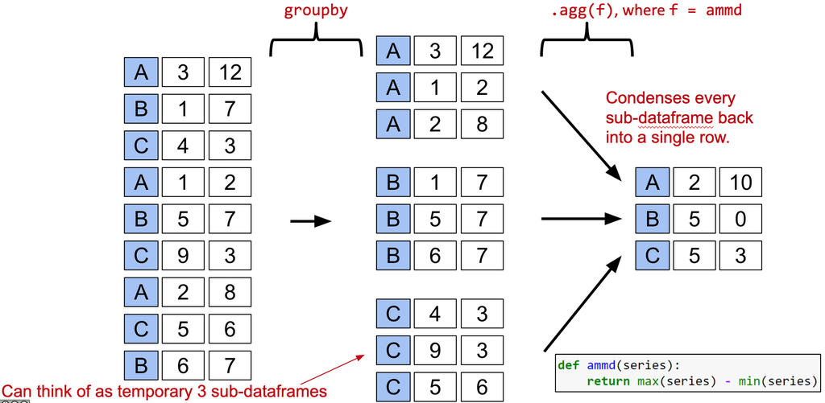

Let's actually build this DataFrame and play with it interactively to understand `groupby` a little better:

```python
d = pd.DataFrame(dict(x=[3,1,4,1,5,9,2,5,6], y=[12,7,3,2,7,3,8,6,7]), index=list('ABCABCACB') )
d
```

|  | x | y |
| --- | --- | --- |
| A | 3 | 12 |
| B | 1 | 7 |
| C | 4 | 3 |
| A | 1 | 2 |
| B | 5 | 7 |
| C | 9 | 3 |
| A | 2 | 8 |
| C | 5 | 6 |
| B | 6 | 7 |

```python
dgb = d.groupby(d.index)
dgb
```

```
<pandas.core.groupby.generic.DataFrameGroupBy object at 0x10d73d8d0>
```

```python
dgb.groups
```

```
{'A': Index(['A', 'A', 'A'], dtype='object'),
 'B': Index(['B', 'B', 'B'], dtype='object'),
 'C': Index(['C', 'C', 'C'], dtype='object')}
```

```python
dgb.groups['A']
```

```
Index(['A', 'A', 'A'], dtype='object')
```

```python
dgb.get_group('A')
```

|  | x | y |
| --- | --- | --- |
| A | 3 | 12 |
| A | 1 | 2 |
| A | 2 | 8 |

```python
dgb.agg(ammd)
```

|  | x | y |
| --- | --- | --- |
| A | 2 | 10 |
| B | 5 | 0 |
| C | 5 | 3 |

## Some Additional Groupby Puzzles

Groupby puzzle #1: To test your understanding, try to interpret the result of the code below.

```python
babynames.head(5)
```

|  | State | Sex | Year | Name | Count |
| --- | --- | --- | --- | --- | --- |
| 306522 | CA | M | 1990 | Louis | 280 |
| 340179 | CA | M | 2003 | Edmund | 14 |
| 60604 | CA | F | 1969 | Micheal | 6 |
| 8678 | CA | F | 1927 | Faye | 26 |
| 83654 | CA | F | 1980 | Antonia | 61 |

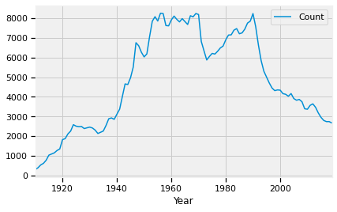

```python
babynames.groupby("Year").agg(ammd).plot();
```

```python
for i, (k, v) in enumerate(babynames.groupby("Year")):
    if i >= 3: break
    print(f"Year: {k}")
    display(v.head())
```

```
Year: 1910
```

|  | State | Sex | Year | Name | Count |
| --- | --- | --- | --- | --- | --- |
| 106 | CA | F | 1910 | Alberta | 14 |
| 64 | CA | F | 1910 | Pearl | 26 |
| 225 | CA | F | 1910 | Margie | 5 |
| 90 | CA | F | 1910 | Ramona | 18 |
| 208 | CA | F | 1910 | Billie | 5 |

```
Year: 1911
```

|  | State | Sex | Year | Name | Count |
| --- | --- | --- | --- | --- | --- |
| 299 | CA | F | 1911 | Ruby | 27 |
| 287 | CA | F | 1911 | Jennie | 32 |
| 427 | CA | F | 1911 | Tillie | 7 |
| 228640 | CA | M | 1911 | Fred | 50 |
| 249 | CA | F | 1911 | Marjorie | 78 |

```
Year: 1912
```

|  | State | Sex | Year | Name | Count |
| --- | --- | --- | --- | --- | --- |
| 671 | CA | F | 1912 | Lila | 10 |
| 592 | CA | F | 1912 | Bessie | 23 |
| 739 | CA | F | 1912 | Erna | 6 |
| 523 | CA | F | 1912 | Betty | 60 |
| 508 | CA | F | 1912 | Hazel | 85 |

For reference, the first 5 values from the plot above are:

```python
babynames.groupby("Year").agg(ammd).head(5)
```

| Year | Count |
| --- | --- |
| 1910 | 290 |
| 1911 | 385 |
| 1912 | 529 |
| 1913 | 609 |
| 1914 | 768 |

#### groupby Puzzle #2

```python
elections = pd.read_csv("elections.csv")
elections.sample(5)
```

|  | Year | Candidate | Party | Popular vote | Result | % |
| --- | --- | --- | --- | --- | --- | --- |
| 175 | 2016 | Gary Johnson | Libertarian | 4489235 | loss | 3.307714 |
| 171 | 2012 | Mitt Romney | Republican | 60933504 | loss | 47.384076 |
| 161 | 2004 | Ralph Nader | Independent | 465151 | loss | 0.380663 |
| 73 | 1916 | Frank Hanly | Prohibition | 221302 | loss | 1.197041 |
| 40 | 1884 | James G. Blaine | Republican | 4856905 | loss | 48.312208 |

We have to be careful when using aggregation functions. For example, the code below might be misinterpreted to say that Woodrow Wilson ran for election in 2016. Why is this happening?

elections.groupby("Party").agg(max).head(10)

```python
elections.groupby("Party").agg(max).head(10)
```

| Party | Year | Candidate | Popular vote | Result | % |
| --- | --- | --- | --- | --- | --- |
| American | 1976 | Thomas J. Anderson | 873053 | loss | 21.554001 |
| American Independent | 1976 | Lester Maddox | 9901118 | loss | 13.571218 |
| Anti-Masonic | 1832 | William Wirt | 100715 | loss | 7.821583 |
| Anti-Monopoly | 1884 | Benjamin Butler | 134294 | loss | 1.335838 |
| Citizens | 1980 | Barry Commoner | 233052 | loss | 0.270182 |
| Communist | 1932 | William Z. Foster | 103307 | loss | 0.261069 |
| Constitution | 2016 | Michael Peroutka | 203091 | loss | 0.152398 |
| Constitutional Union | 1860 | John Bell | 590901 | loss | 12.639283 |
| Democratic | 2016 | Woodrow Wilson | 69498516 | win | 61.344703 |
| Democratic-Republican | 1824 | John Quincy Adams | 151271 | win | 57.210122 |

### groupby puzzle #3

Inspired by above, try to predict the results of the groupby operation shown. The answer is below the image.

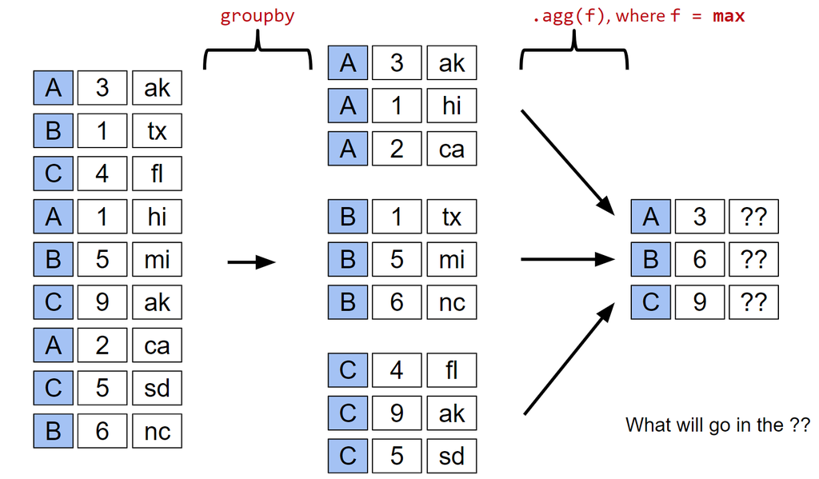

The top ?? will be "hi", the second ?? will be "tx", and the third ?? will be "sd".

```python
ds = pd.DataFrame(dict(x=[3,1,4,1,5,9,2,5,6],
                      y=['ak', 'tx', 'fl', 'hi', 'mi', 'ak', 'ca', 'sd', 'nc']),
                      index=list('ABCABCACB') )
ds
```

|  | x | y |
| --- | --- | --- |
| A | 3 | ak |
| B | 1 | tx |
| C | 4 | fl |
| A | 1 | hi |
| B | 5 | mi |
| C | 9 | ak |
| A | 2 | ca |
| C | 5 | sd |
| B | 6 | nc |

```python
ds.groupby(ds.index).agg(max)
```

|  | x | y |
| --- | --- | --- |
| A | 3 | hi |
| B | 6 | tx |
| C | 9 | sd |

### groupby puzzle #4

Next we'll write code that properly returns *the best result by each party*. That is, each row should show the Year, Candidate, Popular Vote, Result, and % for the election in which that party saw its best results (rather than mixing them as in the example above), here's what the first rows of the correct output should look like:

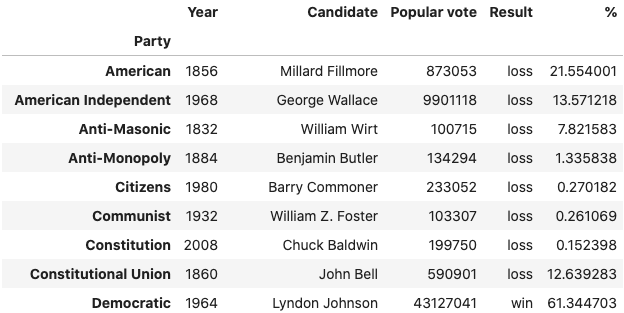

```python
elections_sorted_by_percent = elections.sort_values("%", ascending=False)
elections_sorted_by_percent.head(5)
```

|  | Year | Candidate | Party | Popular vote | Result | % |
| --- | --- | --- | --- | --- | --- | --- |
| 114 | 1964 | Lyndon Johnson | Democratic | 43127041 | win | 61.344703 |
| 91 | 1936 | Franklin Roosevelt | Democratic | 27752648 | win | 60.978107 |
| 120 | 1972 | Richard Nixon | Republican | 47168710 | win | 60.907806 |
| 79 | 1920 | Warren Harding | Republican | 16144093 | win | 60.574501 |
| 133 | 1984 | Ronald Reagan | Republican | 54455472 | win | 59.023326 |

```python
#def get_first(s):
#    return s.iloc[0]

elections_sorted_by_percent = elections.sort_values("%", ascending=False)
elections_sorted_by_percent.groupby("Party").agg(lambda x : x.iloc[0]).head(10)
```

| Party | Year | Candidate | Popular vote | Result | % |
| --- | --- | --- | --- | --- | --- |
| American | 1856 | Millard Fillmore | 873053 | loss | 21.554001 |
| American Independent | 1968 | George Wallace | 9901118 | loss | 13.571218 |
| Anti-Masonic | 1832 | William Wirt | 100715 | loss | 7.821583 |
| Anti-Monopoly | 1884 | Benjamin Butler | 134294 | loss | 1.335838 |
| Citizens | 1980 | Barry Commoner | 233052 | loss | 0.270182 |
| Communist | 1932 | William Z. Foster | 103307 | loss | 0.261069 |
| Constitution | 2008 | Chuck Baldwin | 199750 | loss | 0.152398 |
| Constitutional Union | 1860 | John Bell | 590901 | loss | 12.639283 |
| Democratic | 1964 | Lyndon Johnson | 43127041 | win | 61.344703 |
| Democratic-Republican | 1824 | Andrew Jackson | 151271 | loss | 57.210122 |

You'll soon discover that with Pandas' rich tool set, there's typically more than one way to get to the same answer. Each approach has different tradeoffs in terms of readability, performance, memory consumption, complexity and more. It will take some experience for you to develop a sense of which approach is better for each problem, but you should in general try to think if you can at least envision a different solution to a given problem, especially if you find your current solution to be particularly convoluted or hard to read.

Here's a couple of other ways of obtaining the same result (in each case we only show the top part with `head()`). The first approach uses `groupby` but finds the location of the maximum value via the `idxmax()` method (look up its documentation!). We then index and sort by party to match the requested formatting:

```python
elections.head()
```

|  | Year | Candidate | Party | Popular vote | Result | % |
| --- | --- | --- | --- | --- | --- | --- |
| 0 | 1824 | Andrew Jackson | Democratic-Republican | 151271 | loss | 57.210122 |
| 1 | 1824 | John Quincy Adams | Democratic-Republican | 113142 | win | 42.789878 |
| 2 | 1828 | Andrew Jackson | Democratic | 642806 | win | 56.203927 |
| 3 | 1828 | John Quincy Adams | National Republican | 500897 | loss | 43.796073 |
| 4 | 1832 | Andrew Jackson | Democratic | 702735 | win | 54.574789 |

```python
elections.groupby('Party')['%'].idxmax()
```

```
Party
American                  22
American Independent     115
Anti-Masonic               6
Anti-Monopoly             38
Citizens                 127
Communist                 89
Constitution             164
Constitutional Union      24
Democratic               114
Democratic-Republican      0
Dixiecrat                103
Farmer–Labor              78
Free Soil                 15
Green                    155
Greenback                 35
Independent              143
Liberal Republican        31
Libertarian              175
National Democratic       50
National Republican        3
National Union            27
Natural Law              148
New Alliance             136
Northern Democratic       26
Populist                  48
Progressive               68
Prohibition               49
Reform                   150
Republican               120
Socialist                 66
Southern Democratic       25
States' Rights           110
Taxpayers                147
Union                     93
Union Labor               42
Whig                      11
Name: %, dtype: int64
```

```python
best_per_party = elections.loc[elections.groupby('Party')['%'].idxmax()]  # This is the computational part
best_per_party.set_index('Party').sort_index().head()  # This indexes by Party to match the formatting above
```

| Party | Year | Candidate | Popular vote | Result | % |
| --- | --- | --- | --- | --- | --- |
| American | 1856 | Millard Fillmore | 873053 | loss | 21.554001 |
| American Independent | 1968 | George Wallace | 9901118 | loss | 13.571218 |
| Anti-Masonic | 1832 | William Wirt | 100715 | loss | 7.821583 |
| Anti-Monopoly | 1884 | Benjamin Butler | 134294 | loss | 1.335838 |
| Citizens | 1980 | Barry Commoner | 233052 | loss | 0.270182 |

And this one doesn't even use `groupby`! This approach instead uses the `drop_duplicates` method to keep only the last occurrence of of each party after having sorted by "%", which is the best performance. Again, the 2nd line is purely formatting:

```python
best_per_party2 = elections.sort_values('%').drop_duplicates(['Party'], keep='last')
best_per_party2.set_index('Party').sort_index().head()  # Formatting
```

| Party | Year | Candidate | Popular vote | Result | % |
| --- | --- | --- | --- | --- | --- |
| American | 1856 | Millard Fillmore | 873053 | loss | 21.554001 |
| American Independent | 1968 | George Wallace | 9901118 | loss | 13.571218 |
| Anti-Masonic | 1832 | William Wirt | 100715 | loss | 7.821583 |
| Anti-Monopoly | 1884 | Benjamin Butler | 134294 | loss | 1.335838 |
| Citizens | 1980 | Barry Commoner | 233052 | loss | 0.270182 |

*Challenge:* see if you can find yet another approach that still gives the same answer.

## Other groupby Features

### groupby.size()

```python
elections.groupby("Party")
```

```
<pandas.core.groupby.generic.DataFrameGroupBy object at 0x1a2d251ed0>
```

```python
#size returns a Series giving the size of each group
elections.groupby("Party").size().head(15)
```

```
Party
American                  2
American Independent      3
Anti-Masonic              1
Anti-Monopoly             1
Citizens                  1
Communist                 1
Constitution              3
Constitutional Union      1
Democratic               46
Democratic-Republican     2
Dixiecrat                 1
Farmer–Labor              1
Free Soil                 2
Green                     6
Greenback                 1
dtype: int64
```

### groupby.filter()

```python
# filter gives a copy of the original DataFrame where row r is included
# if its group obeys the given condition
#
# Note: Filtering is done per GROUP, not per ROW.
elections.groupby("Year").filter(lambda sf: sf["%"].max() < 45)
```

|  | Year | Candidate | Party | Popular vote | Result | % |
| --- | --- | --- | --- | --- | --- | --- |
| 23 | 1860 | Abraham Lincoln | Republican | 1855993 | win | 39.699408 |
| 24 | 1860 | John Bell | Constitutional Union | 590901 | loss | 12.639283 |
| 25 | 1860 | John C. Breckinridge | Southern Democratic | 848019 | loss | 18.138998 |
| 26 | 1860 | Stephen A. Douglas | Northern Democratic | 1380202 | loss | 29.522311 |
| 66 | 1912 | Eugene V. Debs | Socialist | 901551 | loss | 6.004354 |
| 67 | 1912 | Eugene W. Chafin | Prohibition | 208156 | loss | 1.386325 |
| 68 | 1912 | Theodore Roosevelt | Progressive | 4122721 | loss | 27.457433 |
| 69 | 1912 | William Taft | Republican | 3486242 | loss | 23.218466 |
| 70 | 1912 | Woodrow Wilson | Democratic | 6296284 | win | 41.933422 |
| 115 | 1968 | George Wallace | American Independent | 9901118 | loss | 13.571218 |
| 116 | 1968 | Hubert Humphrey | Democratic | 31271839 | loss | 42.863537 |
| 117 | 1968 | Richard Nixon | Republican | 31783783 | win | 43.565246 |
| 139 | 1992 | Andre Marrou | Libertarian | 290087 | loss | 0.278516 |
| 140 | 1992 | Bill Clinton | Democratic | 44909806 | win | 43.118485 |
| 141 | 1992 | Bo Gritz | Populist | 106152 | loss | 0.101918 |
| 142 | 1992 | George H. W. Bush | Republican | 39104550 | loss | 37.544784 |
| 143 | 1992 | Ross Perot | Independent | 19743821 | loss | 18.956298 |

```python
for i, (n, g) in enumerate(elections.groupby("Party")):
    print(n)
    display(g.head(2))
    if i>3: break
```

```
American
```

|  | Year | Candidate | Party | Popular vote | Result | % |
| --- | --- | --- | --- | --- | --- | --- |
| 22 | 1856 | Millard Fillmore | American | 873053 | loss | 21.554001 |
| 126 | 1976 | Thomas J. Anderson | American | 158271 | loss | 0.194862 |

```
American Independent
```

|  | Year | Candidate | Party | Popular vote | Result | % |
| --- | --- | --- | --- | --- | --- | --- |
| 115 | 1968 | George Wallace | American Independent | 9901118 | loss | 13.571218 |
| 119 | 1972 | John G. Schmitz | American Independent | 1100868 | loss | 1.421524 |

```
Anti-Masonic
```

|  | Year | Candidate | Party | Popular vote | Result | % |
| --- | --- | --- | --- | --- | --- | --- |
| 6 | 1832 | William Wirt | Anti-Masonic | 100715 | loss | 7.821583 |

```
Anti-Monopoly
```

|  | Year | Candidate | Party | Popular vote | Result | % |
| --- | --- | --- | --- | --- | --- | --- |
| 38 | 1884 | Benjamin Butler | Anti-Monopoly | 134294 | loss | 1.335838 |

```
Citizens
```

|  | Year | Candidate | Party | Popular vote | Result | % |
| --- | --- | --- | --- | --- | --- | --- |
| 127 | 1980 | Barry Commoner | Citizens | 233052 | loss | 0.270182 |

### groupby.sum(), groupby.mean(), etc.

As an alternative to groupby.agg(sum), we can also simply do groupby.sum().

```python
elections.groupby("Year").agg(sum).head()
```

| Year | Popular vote | % |
| --- | --- | --- |
| 1824 | 264413 | 100.0 |
| 1828 | 1143703 | 100.0 |
| 1832 | 1287655 | 100.0 |
| 1836 | 1460216 | 100.0 |
| 1840 | 2404437 | 100.0 |

```python
elections.groupby("Year").sum().head()
```

| Year | Popular vote | % |
| --- | --- | --- |
| 1824 | 264413 | 100.0 |
| 1828 | 1143703 | 100.0 |
| 1832 | 1287655 | 100.0 |
| 1836 | 1460216 | 100.0 |
| 1840 | 2404437 | 100.0 |

The same applies for many other common operations.

```python
elections.groupby("Year").agg(max).head()
```

| Year | Candidate | Party | Popular vote | Result | % |
| --- | --- | --- | --- | --- | --- |
| 1824 | John Quincy Adams | Democratic-Republican | 151271 | win | 57.210122 |
| 1828 | John Quincy Adams | National Republican | 642806 | win | 56.203927 |
| 1832 | William Wirt | National Republican | 702735 | win | 54.574789 |
| 1836 | William Henry Harrison | Whig | 763291 | win | 52.272472 |
| 1840 | William Henry Harrison | Whig | 1275583 | win | 53.051213 |

```python
elections.groupby("Year").max().head()
```

| Year | Candidate | Party | Popular vote | Result | % |
| --- | --- | --- | --- | --- | --- |
| 1824 | John Quincy Adams | Democratic-Republican | 151271 | win | 57.210122 |
| 1828 | John Quincy Adams | National Republican | 642806 | win | 56.203927 |
| 1832 | William Wirt | National Republican | 702735 | win | 54.574789 |
| 1836 | William Henry Harrison | Whig | 763291 | win | 52.272472 |
| 1840 | William Henry Harrison | Whig | 1275583 | win | 53.051213 |

```python
#elections.groupby("Year").mean().head()
#elections.groupby("Year").median().head()
elections.groupby("Year").max().head()
```

| Year | Candidate | Party | Popular vote | Result | % |
| --- | --- | --- | --- | --- | --- |
| 1824 | John Quincy Adams | Democratic-Republican | 151271 | win | 57.210122 |
| 1828 | John Quincy Adams | National Republican | 642806 | win | 56.203927 |
| 1832 | William Wirt | National Republican | 702735 | win | 54.574789 |
| 1836 | William Henry Harrison | Whig | 763291 | win | 52.272472 |
| 1840 | William Henry Harrison | Whig | 1275583 | win | 53.051213 |

## Pivot Tables

It is possible to group a DataFrame by multiple features. For example, if we group by Year and Sex we get back a DataFrame with the total number of babies of each sex born in each year.

```python
babynames.groupby(["Year", "Sex"]).agg(sum).head(6)
```

| Year | Sex | Count |
| --- | --- | --- |
| 1910 | F | 5950 |
|  | M | 3213 |
| 1911 | F | 6602 |
|  | M | 3381 |
| 1912 | F | 9803 |
|  | M | 8142 |

```python
babynames.groupby(["Sex", "Year"]).agg(sum).head(6)
```

| Sex | Year | Count |
| --- | --- | --- |
| F | 1910 | 5950 |
|  | 1911 | 6602 |
|  | 1912 | 9803 |
|  | 1913 | 11860 |
|  | 1914 | 13815 |
|  | 1915 | 18643 |

```python
babynames.head(10)
```

|  | State | Sex | Year | Name | Count |
| --- | --- | --- | --- | --- | --- |
| 306522 | CA | M | 1990 | Louis | 280 |
| 340179 | CA | M | 2003 | Edmund | 14 |
| 60604 | CA | F | 1969 | Micheal | 6 |
| 8678 | CA | F | 1927 | Faye | 26 |
| 83654 | CA | F | 1980 | Antonia | 61 |
| 220497 | CA | F | 2017 | Kayliana | 6 |
| 364174 | CA | M | 2011 | Townes | 6 |
| 18535 | CA | F | 1941 | Robert | 7 |
| 107131 | CA | F | 1988 | Brian | 15 |
| 248335 | CA | M | 1947 | Santos | 14 |

```python
babynames.groupby(["Count", "Year", "Sex"]).agg(sum).head(6)
```

| Count | Year | Sex | State | Name |
| --- | --- | --- | --- | --- |
| 5 | 1910 | F | CACACACACACACACACACACACACACACACACACACACACACACA... | MargieBillieTillieFayeMercedesEveRenaIlaJacque... |
|  |  | M | CACACACACACACACACACACACACACACACACA | LelandTomGuadalupeFloydAlexOliverStephenBenjam... |
|  | 1911 | F | CACACACACACACACACACACACACACACACACACACACACACACA... | LeolaJulietCorneliaBeverlyLeilaMamieReginaSueS... |
|  |  | M | CACACACACACACACACACACACACACACACACACA | MarvinAlanMerleOliverRogerRonaldHomerPhillipLo... |
|  | 1912 | F | CACACACACACACACACACACACACACACACACACACACACACACA... | MargretBillieMaudeLeolaTeresaChristinaFerneBer... |
|  |  | M | CACACACACACACACACACACACACACACACACACACACACACACA... | ClintonErwinPatrickNoelMyronMortonBeverlyBobEm... |

The DataFrame resulting from the aggregation operation is now multi-indexed. That is, it has more than one dimension to its index. We will explore this in next week's exercises.

### Goal 5: Finding the number of babies born in each year of each sex.

Suppose we want to build a table showing the total number of babies born of each sex in each year. One way is to groupby using both columns of interest.

```python
babynames.groupby(["Year", "Sex"]).agg(sum).head(6)
```

| Year | Sex | Count |
| --- | --- | --- |
| 1910 | F | 5950 |
|  | M | 3213 |
| 1911 | F | 6602 |
|  | M | 3381 |
| 1912 | F | 9803 |
|  | M | 8142 |

A more natural approach is to use a pivot table (like we saw in data 8).

```python
babynames.head(5)
```

|  | State | Sex | Year | Name | Count |
| --- | --- | --- | --- | --- | --- |
| 306522 | CA | M | 1990 | Louis | 280 |
| 340179 | CA | M | 2003 | Edmund | 14 |
| 60604 | CA | F | 1969 | Micheal | 6 |
| 8678 | CA | F | 1927 | Faye | 26 |
| 83654 | CA | F | 1980 | Antonia | 61 |

```python
babynames_pivot = babynames.pivot_table(
    index='Year', # the rows (turned into index)
    columns='Sex', # the column values
    values=['Count', 'Name'], # the field(s) to processed in each group
    aggfunc=np.max, # group operation
)
babynames_pivot.head(6)
```

| Sex Year | Count F | Count M | Name F | Name M |
| --- | --- | --- | --- | --- |
| 1910 | 295 | 237 | Yvonne | William |
| 1911 | 390 | 214 | Zelma | Willis |
| 1912 | 534 | 501 | Yvonne | Woodrow |
| 1913 | 584 | 614 | Zelma | Yoshio |
| 1914 | 773 | 769 | Zelma | Yoshio |
| 1915 | 998 | 1033 | Zita | Yukio |

The basic idea behind pivot tables is shown in the image below.

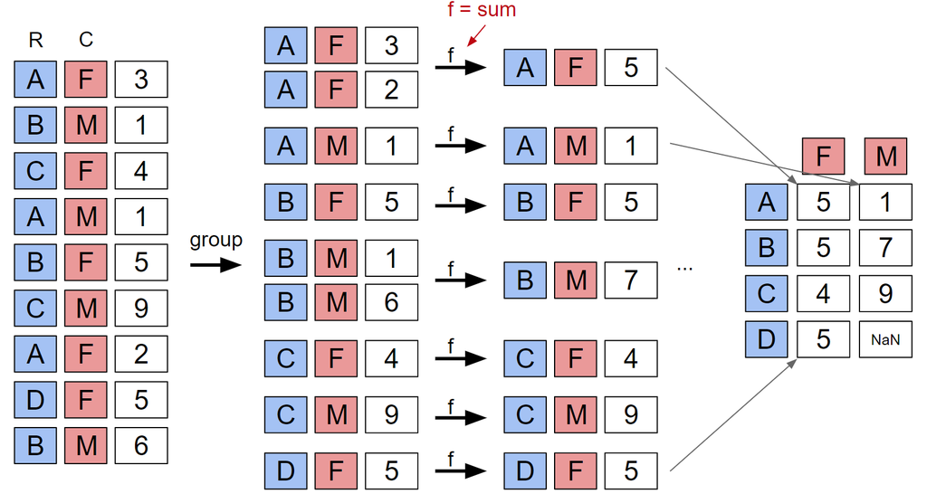

### groupby puzzle #5: More careful look at the most popular 2018 name in California.

In goal 1, we didn't take into account the unlikely possibility that the most popular name was actually spread across both birth sexes. For example, what if in the table below it turns out that there were 300 female Noahs born in CA in 2018. In that case, Noah would actually be the most popular.

Since our queries are getting pretty long, I've stuck them inside parentheses which allows us to spread them over many lines.

```python
(
babynames[babynames["Year"] == 2018]
    .sort_values(by = "Count", ascending = False)
    .head(5)
)
```

|  | State | Sex | Year | Name | Count |
| --- | --- | --- | --- | --- | --- |
| 221154 | CA | F | 2018 | Emma | 2741 |
| 382082 | CA | M | 2018 | Noah | 2567 |
| 221155 | CA | F | 2018 | Mia | 2497 |
| 221156 | CA | F | 2018 | Olivia | 2464 |
| 382083 | CA | M | 2018 | Liam | 2411 |

Try to add a single line to the operation above so that each row represents the sum of male and female babies born in 2018 with that name. To do this, fill in the ??? below.

```python
(
babynames[babynames["Year"] == 2018]
    #.???
    .sort_values(by = "Count", ascending = False)
    .head(5)
)
```

|  | State | Sex | Year | Name | Count |
| --- | --- | --- | --- | --- | --- |
| 221154 | CA | F | 2018 | Emma | 2741 |
| 382082 | CA | M | 2018 | Noah | 2567 |
| 221155 | CA | F | 2018 | Mia | 2497 |
| 221156 | CA | F | 2018 | Olivia | 2464 |
| 382083 | CA | M | 2018 | Liam | 2411 |

```python
def ammd2(L):
    return max(L) - min(L)

print(ammd2([1, 2, 3, 4, 5]))
```

```
4
```

```python
ammd2 = lambda L: max(L) - min(L)
print(ammd2([1, 2, 3, 4, 5]))
```

```
4
```